# TUGAS MINGGU 2 MPDW

Fajryanti Kusuma Wardani

2023-09-05

```r
library(dplyr)
library(TTR)
library(forecast)
library(lmtest) #digunakan untuk uji formal pendeteksian autokorelasi
library(orcutt) #untuk membuat model regresi Cochrane-Orcutt
library(HoRM) #untuk membuat model regresi Hildreth-Lu
```

```r
#IMPOR DATA
library("rio")
data <- import("https://raw.githubusercontent.com/fajryanti/mpdw-p1/main/PRAKTIKUM%20MINGGU%202/new%20delhi%20air%20quality.csv")

y <- as.matrix(data[,2])
a <- rep(1, nrow(data))
x <- as.matrix((cbind(a, data[,3], data[,6])))
```

```r
#Eksplorasi data
str(data)
```

```
## 'data.frame':    72 obs. of  12 variables:
##  $ V1             : int  0 1 2 3 4 5 6 7 8 9 ...
##  $ AQI            : num  30.2 28.2 26.6 25 26 26 26 24 23 24 ...
##  $ CO             : num  199 198 199 202 205 ...
##  $ datetime       : chr  "2022-10-21:18" "2022-10-21:19" "2022-10-21:20" "2022-10-21:21" ...
##  $ no2            : num  0.0469 0.0465 0.0469 0.0482 0.0489 ...
##  $ o3             : num  55.8 54.9 54.6 55.1 55.8 ...
##  $ pm10           : num  10.5 10.7 11.2 11.1 10.4 ...
##  $ pm25           : num  5.64 4.62 3.52 2.23 1.98 ...
##  $ so2            : num  0.387 0.41 0.402 0.376 0.339 ...
##  $ timestamp_local: POSIXct, format: "2022-10-21 23:00:00" "2022-10-22 00:00:00" ...
##  $ timestamp_utc  : POSIXct, format: "2022-10-21 18:00:00" "2022-10-21 19:00:00" ...
##  $ ts             : int  1666375200 1666378800 1666382400 1666386000 1666389600 1666393200 1666396800 1666400400 1666404000 1666407600 ...
```

```r
dim(data)
```

```
## [1] 72 12
```

```r
#MATRIKS X'X
xtx <- t(x)%*%x
xtx
```

```
##           a
## a    72.000   14406.87   4073.167
##   14406.872 2884197.12 816731.912
##    4073.167  816731.91 233363.127
```

```r
#MATRIKS (X'X)^-1
xtx.inv <- solve(xtx)
xtx.inv
```

```
##            a
## a 62.8822773 -0.369576178  0.195894920
##   -0.3695762  0.002210901 -0.001287127
##    0.1958949 -0.001287127  0.001089826
```

```r
#MATRIKS X'Y
xty <- t(x)%*%y
xty
```

```
##       [,1]
## a   1885.0
##   377961.1
##   107995.8
```

```r
#PENDUGA PARAMETER
b <- xtx.inv%*%xty
b
```

```
##          [,1]
## a  3.52239128
##   -0.02094453
##    0.47460197
```

```r
#ANOVA
model <- lm(data$AQI ~ data$CO+data$o3)
model
```

```
##
## Call:
## lm(formula = data$AQI ~ data$CO + data$o3)
##
## Coefficients:
## (Intercept)      data$CO      data$o3
##     3.52239     -0.02094      0.47460
```

```r
anova(model)
```

```
## Analysis of Variance Table
##
## Response: data$AQI
##           Df Sum Sq Mean Sq F value    Pr(>F)
## data$CO    1 421.49  421.49  847.38 < 2.2e-16 ***
## data$o3    1 206.68  206.68  415.52 < 2.2e-16 ***
## Residuals 69  34.32    0.50
## ---
## Signif. codes:  0 '***' 0.001 '**' 0.01 '*' 0.05 '.' 0.1 ' ' 1
```

```r
summary(model)
```

```
##
## Call:
## lm(formula = data$AQI ~ data$CO + data$o3)
##
## Residuals:
##     Min      1Q  Median      3Q     Max
## -0.5528 -0.3667 -0.1130  0.1647  4.3592
##
## Coefficients:
##             Estimate Std. Error t value Pr(>|t|)
## (Intercept)  3.52239    5.59265   0.630    0.531
## data$CO     -0.02094    0.03316  -0.632    0.530
## data$o3      0.47460    0.02328  20.384   <2e-16 ***
## ---
## Signif. codes:  0 '***' 0.001 '**' 0.01 '*' 0.05 '.' 0.1 ' ' 1
##
## Residual standard error: 0.7053 on 69 degrees of freedom
## Multiple R-squared:  0.9482, Adjusted R-squared:  0.9467
## F-statistic: 631.5 on 2 and 69 DF,  p-value: < 2.2e-16
```

Model yang dihasilkan adalah
$$AQI_i=3.52239-0.02094CO_i+0.47460O3_i$$

p-value = 2.2e-16 alfa = 0,05 maka p-value < alfa maka tolak H0, artinya minimal ada satu peubah penjelas yang berpengaruh terhadap peubah respon

```r
# Pengujian Asumsi
## Uji Multikolinearitas
car::vif(model)
```

```
##  data$CO  data$o3
## 3.200712 3.200712
```

`Nilai VIF` pada setiap peubah penjelas < 10. Artinya, tidak terjadi multikolinearitas pada peubah penjelas yang digunakan

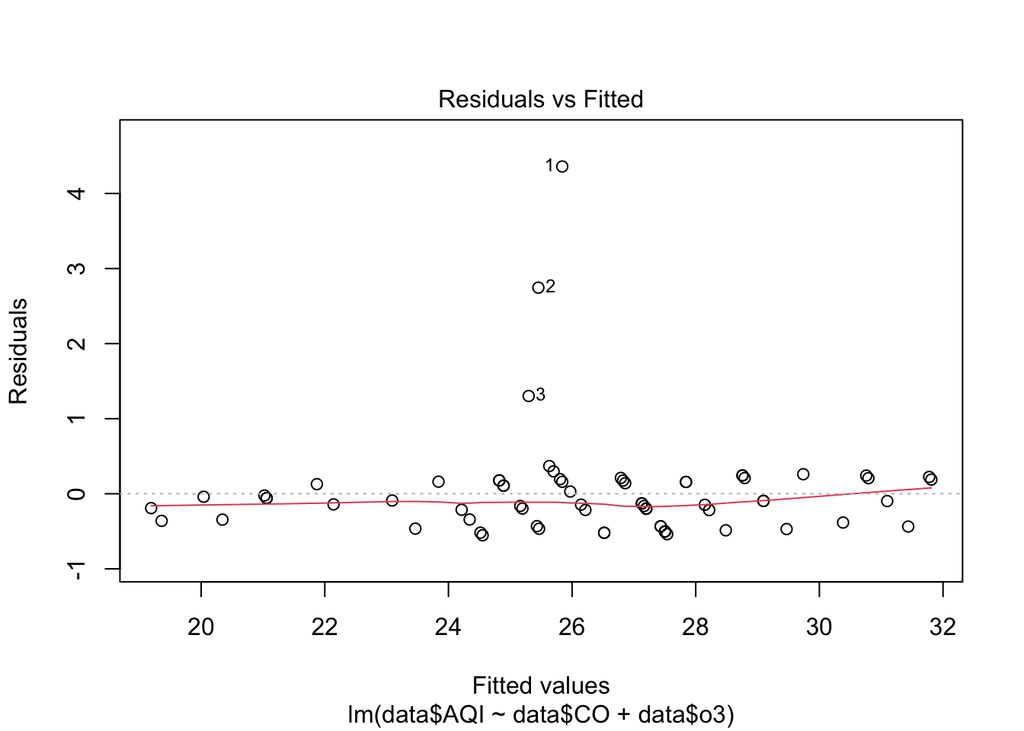

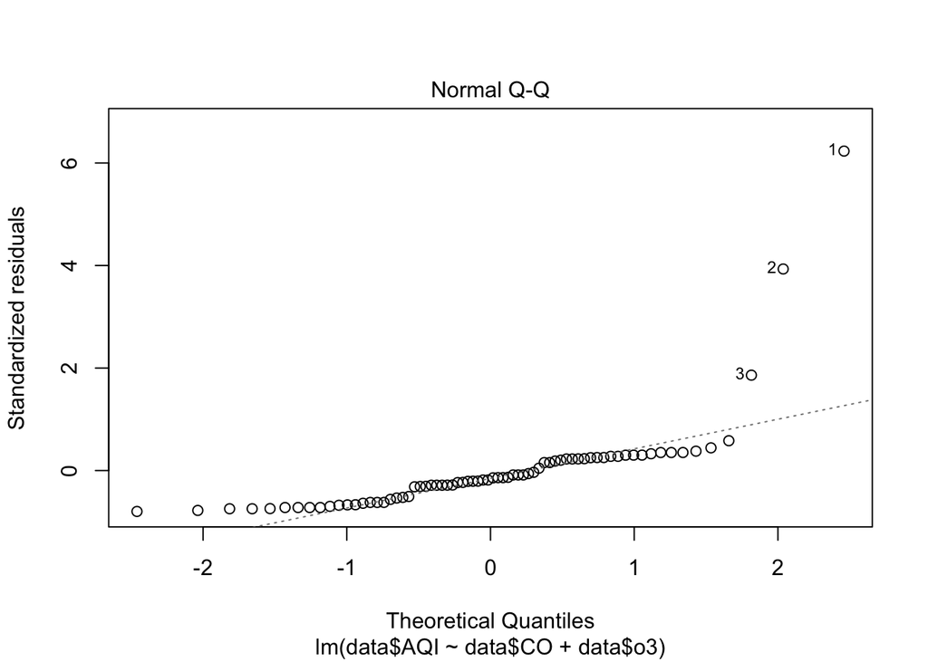

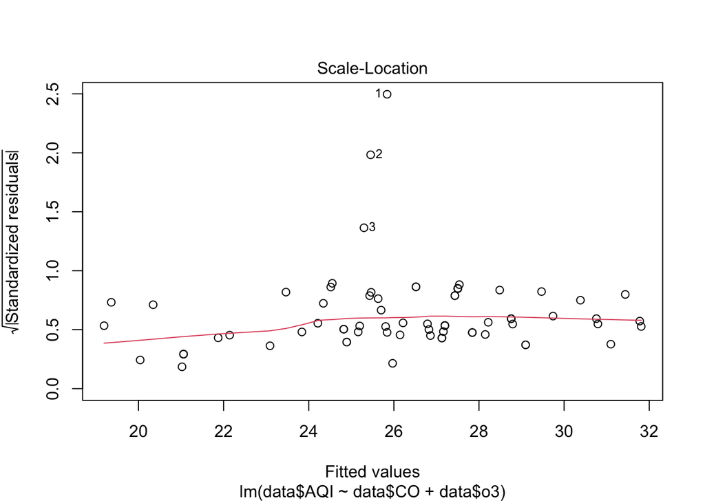

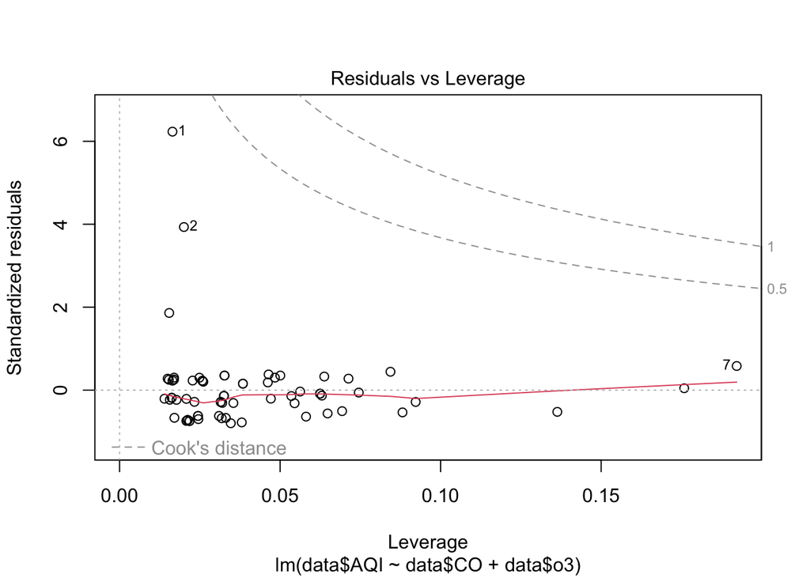

```r
## Sisaan menyebar normal
plot(model)
```

```r
## Nilai harapan sisaan sama dengan nol
# Uji t
t.test(resid(model), mu = 0,)
```

```
##
##  One Sample t-test
##
## data:  resid(model)
## t = 2.9165e-15, df = 71, p-value = 1
## alternative hypothesis: true mean is not equal to 0
## 95 percent confidence interval:
##  -0.1633788  0.1633788
## sample estimates:
##    mean of x
## 2.389732e-16
```

$p-value=1 > 0.1$ (tidak tolak $H_0$) Artinya: Nilai harapan sisaan sama dengan nol

```r
## Ragam sisaan homogen
# Uji Breusch-Pagan
lmtest::bptest(model)
```

```
##
##  studentized Breusch-Pagan test
##
## data:  model
## BP = 0.44539, df = 2, p-value = 0.8004
```

$p-value=0.8004 > 0.1$ (tak tolak $H_0$) Artinya: Ragam sisaan homogen

```r
#Deteksi autokorelasi dengan uji-Durbin Watson
#H0: tidak ada autokorelasi
#H1: ada autokorelasi
dwtest(model)
```

```
##
##  Durbin-Watson test
##
## data:  model
## DW = 0.53581, p-value = 7.677e-15
## alternative hypothesis: true autocorrelation is greater than 0
```

Berdasarkan hasil DW Test, didapatkan nilai $DW = 0.53581$ dan *p-value* = $7.6773e-15$. Berdasarkan tabel Durbin-Watson diperoleh nilai $DL = 1.5611$ dan $DU = 1.6751$. Nilai DW tidak berada di antara nilai DL dan DU. Artinya, terindikasi kuat adanya autocorrelation positif dalam residu, yang berarti bahwa terdapat pola hubungan positif antara nilai-nilai residu berturut-turut. Namun, dengan nilai *p-value* < 0.05 dapat disimpulkan bahwa tolak H0, cukup bukti mengatakan adanya autokorelasi. Oleh karena itu, diperlukan penangan autokorelasi. Penanganan yang akan digunakan menggunakan dua metode, yaitu Cochrane-Orcutt dan Hildret-Lu.

```r
## Penanganan Autokorelasi
### Metode Cochrane-Orcutt
#Penanganan Autokorelasi Cochrane-Orcutt
modelCO<-cochrane.orcutt(model)
modelCO
```

```
## Cochrane-orcutt estimation for first order autocorrelation
##
## Call:
## lm(formula = data$AQI ~ data$CO + data$o3)
##
##  number of interaction: 8
##  rho 0.461077
##
## Durbin-Watson statistic
## (original):    0.53581 , p-value: 7.677e-15
## (transformed): 2.71726 , p-value: 9.983e-01
##
##  coefficients:
## (Intercept)     data$CO     data$o3
##    4.946657   -0.031304    0.484000
```

```r
#Rho optimum
rho<- modelCO$rho
rho
```

```
## [1] 0.4610774
```

```r
#Transformasi Manual
#tanpa data pertama - tanpa data terakhir
aqi.trans <- data$AQI[-1]-data$AQI[-72]*rho
CO.trans <- data$CO[-1]-data$CO[-72]*rho
O3.trans <- data$o3[-1]-data$o3[-72]*rho

#Membentuk model dengan peubah yang sudah ditransformasi
modelCOmanual<- lm(aqi.trans~CO.trans+O3.trans)
summary(modelCOmanual)
```

```
##
## Call:
## lm(formula = aqi.trans ~ CO.trans + O3.trans)
##
## Residuals:
##      Min       1Q   Median       3Q      Max
## -0.93687 -0.23246  0.04246  0.18371  0.79204
##
## Coefficients:
##             Estimate Std. Error t value Pr(>|t|)
## (Intercept)  2.66587    2.25114   1.184    0.240
## CO.trans    -0.03130    0.02468  -1.268    0.209
## O3.trans     0.48400    0.01803  26.837   <2e-16 ***
## ---
## Signif. codes:  0 '***' 0.001 '**' 0.01 '*' 0.05 '.' 0.1 ' ' 1
##
## Residual standard error: 0.341 on 68 degrees of freedom
## Multiple R-squared:  0.9635, Adjusted R-squared:  0.9624
## F-statistic:   898 on 2 and 68 DF,  p-value: < 2.2e-16
```

```r
#Mencari Penduga Koefisien Regresi setelah Transformasi ke Persamaan Awal
#b0 bintang = menghapus koefisien b1,b2,b3 dari model
b0bintang <- modelCOmanual$coefficients[-c(2,3,4)]
b0 <- b0bintang/(1-rho)

#b1 = menghapus koefisien b0,b2,b3 dari model
b1 <- modelCOmanual$coefficients[-c(1,3,4)]

#b2 = menghapus koefisien b0,b1,b3 dari model
b2 <- modelCOmanual$coefficients[-c(1,2,4)]

b0;b1;b2
```

```
## (Intercept)
##    4.946657
```

```
##    CO.trans
## -0.03130417
```

```
##  O3.trans
## 0.4839999
```

```r
### Metode Hildreth-Lu
#Penanganan Autokorelasi Hildreth lu
# Hildreth-Lu
hildreth.lu.func<- function(r, model){
  x1 <- model.matrix(model)[,2]
  x2 <- model.matrix(model)[,3]
  y <- model.response(model.frame(model))
  n <- length(y)
  t <- 2:n
  y <- y[t]-r*y[t-1]
  x1 <- x1[t]-r*x1[t-1]
  x2 <- x2[t]-r*x2[t-1]

  return(lm(y~x1+x2))
}

#Pencariab rho yang meminimumkan SSE
r <- c(seq(0.1,0.9, by= 0.1))
tab <- data.frame("rho" = r, "SSE" = sapply(r, function(i){deviance(hildreth.lu.func(i, model))}))
round(tab, 4)
```

```
##   rho     SSE
## 1 0.1 12.2384
## 2 0.2 10.1596
## 3 0.3  8.7585
## 4 0.4  8.0277
## 5 0.5  7.9550
## 6 0.6  8.5245
## 7 0.7  9.7209
## 8 0.8 11.5415
## 9 0.9 14.0117
```

Pertama-tama akan dicari di mana kira-kira $ρ$ yang menghasilkan SSE minimum. Pada hasil di atas terlihat $ρ$ minimum ketika 0.5. Namun, hasil tersebut masih kurang teliti sehingga akan dicari kembali $ρ$ yang lebih optimum dengan ketelitian yang lebih. Jika sebelumnya jarak antar $ρ$ yang dicari adalah 0.1, kali ini jarak antar $ρ$ adalah 0.001 dan dilakukan pada selang 0.2 sampai dengan 0.5.

```r
#Rho optimal di sekitar 0.4
rOpt <- seq(0.2,0.5, by= 0.001)
tabOpt <- data.frame("rho" = rOpt, "SSE" = sapply(rOpt, function(i){deviance(hildreth.lu.func(i, model))}))
head(tabOpt[order(tabOpt$SSE),])
```

```
##       rho      SSE
## 262 0.461 7.905996
## 263 0.462 7.906024
## 261 0.460 7.906034
## 264 0.463 7.906116
## 260 0.459 7.906136
## 265 0.464 7.906273
```

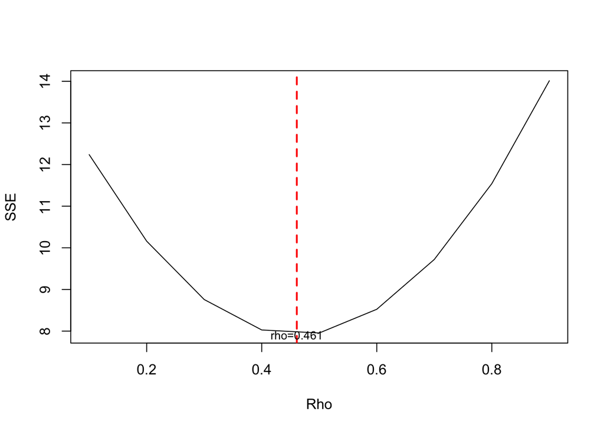

```r
#Grafik SSE optimum
par(mfrow = c(1,1))
plot(tab$SSE ~ tab$rho , type = "l", xlab = "Rho", ylab = "SSE")
abline(v = tabOpt[tabOpt$SSE==min(tabOpt$SSE),"rho"], lty = 2, col="red",lwd=2)
text(x=0.461, y=7.905986, labels = "rho=0.461", cex = 0.8)
```

```r
#Model terbaik
modelHL <- hildreth.lu.func(0.459, model)
summary(modelHL)
```

```
##
## Call:
## lm(formula = y ~ x1 + x2)
##
## Residuals:
##      Min       1Q   Median       3Q      Max
## -0.93476 -0.23229  0.04243  0.18406  0.80125
##
## Coefficients:
##             Estimate Std. Error t value Pr(>|t|)
## (Intercept)  2.65898    2.25530   1.179    0.243
## x1          -0.03110    0.02463  -1.263    0.211
## x2           0.48386    0.01799  26.894   <2e-16 ***
## ---
## Signif. codes:  0 '***' 0.001 '**' 0.01 '*' 0.05 '.' 0.1 ' ' 1
##
## Residual standard error: 0.341 on 68 degrees of freedom
## Multiple R-squared:  0.9637, Adjusted R-squared:  0.9627
## F-statistic: 903.6 on 2 and 68 DF,  p-value: < 2.2e-16
```

```r
#Transformasi Balik
cat("y = ", coef(modelHL)[1]/(1-0.459), "+", coef(modelHL)[2],"x1", "+", coef(modelHL)[3],"x2",sep = "")
```

```
## y = 4.914933+-0.03110454x1+0.4838629x2
```

Setelah dilakukan tranformasi balik, didapatkan model dengan metode Hildreth-Lu sebagai berikut.
$$y_i=4.914933-0.03110454x1_i+0.483629x2_i$$

```r
#Deteksi autokorelasi
dwtest(modelHL)
```

```
##
##  Durbin-Watson test
##
## data:  modelHL
## DW = 2.7123, p-value = 0.9982
## alternative hypothesis: true autocorrelation is greater than 0
```

Terakhir, akan dibandingkan nilai SSE dari ketiga metode (metode awal, metode Cochrane-Orcutt, dan Hildreth-Lu).

```r
#Perbandingan
sseModelawal <- anova(model)$`Sum Sq`[3]
sseModelCO <- anova(modelCOmanual)$`Sum Sq`[3]
sseModelHL <- anova(modelHL)$`Sum Sq`[3]
mseModelawal <- sseModelawal/length(data$AQI)
mseModelCO <- sseModelCO/length(data$AQI)
mseModelHL <- sseModelHL/length(data$AQI)
akurasi <- matrix(c(sseModelawal,sseModelCO,sseModelHL,
                    mseModelawal,mseModelCO,mseModelHL),nrow=2,ncol=3,byrow = T)
colnames(akurasi) <- c("Model Awal", "Model Cochrane-Orcutt", "Model Hildreth-Lu")
row.names(akurasi) <- c("SSE","MSE")
akurasi
```

```
##     Model Awal Model Cochrane-Orcutt Model Hildreth-Lu
## SSE 34.3207491             7.9059961         7.9061362
## MSE  0.4766771             0.1098055         0.1098074
```

Hasil penanganan autokorelasi dengan metode Cochrane-Orcutt dan Hildreth-Lu memiliki nilai `SSE` sebesar $7.9059$ dan $7.9061$. Jauh lebih rendah dibandingkan model awal dengan SSE sebesar $34.3207$. Hal ini menunjukkan bahwa model setelah penanganan lebih baik dibandingkan model awal ketika autokorelasi masih terjadi.

Kesimpulan: Pada data yang digunakan, metode Cochrane-Orcutt dan Hildreth-Lu terbukti efektif dalam menangani autokorelasi.